# Monte Carlo Testing: Additional Examples

### Standard Deviation of Differences

Again note that this is a two-tailed test, because if the variation is too high or too low that would be evidence of nonrandomness.

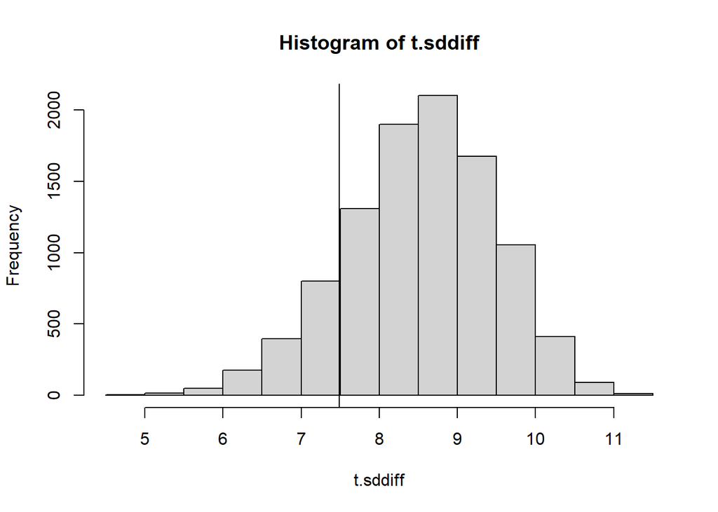

```r
calc_sd_diff <- function(numbers){
 return(sd(diff(numbers) ))
}

NMC <- 10000
t.sddiff <- 0
for(i in 1:NMC){
  t.sddiff[i] <- calc_sd_diff(generate_numbers(20))
}
hist(t.sddiff)
abline(v=calc_sd_diff(numbers.obs))
```

```r
2*min(mean(t.sddiff <= calc_sd_diff(numbers.obs)),
      mean(t.sddiff >= calc_sd_diff(numbers.obs)))
```

```
## [1] 0.281
```

### Mean absolute difference

Another statistic we could look at is related to the *absolute values* of the differences - the average absolute difference. Again- this is a two-tailed test. Too high or too low would be evidence of nonrandomness.

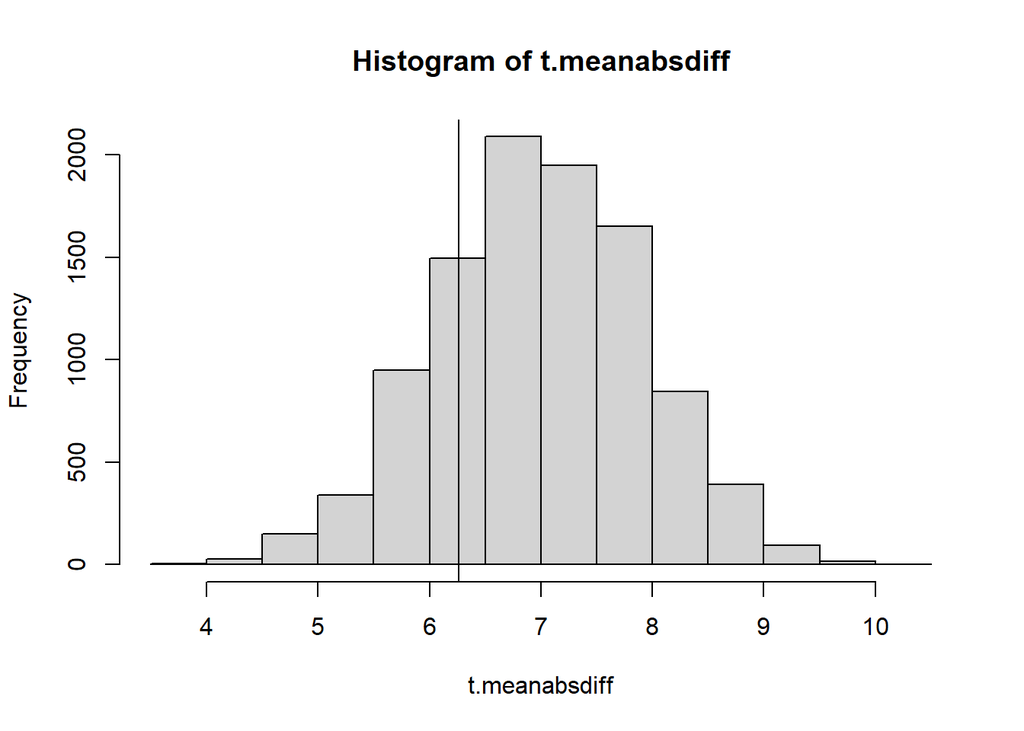

```r
calc_mean_abs_diff <- function(numbers){
 return(mean(abs(diff(numbers))))
}

NMC <- 10000
t.meanabsdiff <- 0
for(i in 1:NMC){
  t.meanabsdiff[i] <- calc_mean_abs_diff(generate_numbers(20))
}
hist(t.meanabsdiff)
abline(v=calc_mean_abs_diff(numbers.obs))
```

```r
2*min(mean(t.meanabsdiff <= calc_mean_abs_diff(numbers.obs)),
      mean(t.meanabsdiff >= calc_mean_abs_diff(numbers.obs)))
```

```
## [1] 0.4436
```

No evidence of nonrandomness! We could be pretty satisfied that the string of integers was properly shuffled by a computer.

What about this one?

2 9 3 13 18 4 17 10 1 15 7 5 12 20 6 19 8 16 14 11

Do you think this was generated by computer or by human?

```r
new.obs.data<- c(2,9,3,13,18,4,17,10,1,15,7,5,12,20,6,19,8,16,14,11)

#Positive Differences
2*min(mean(t.posdiff >= count_pos_diff(new.obs.data)),
    mean(t.posdiff <= count_pos_diff(new.obs.data)))
```

```
## [1] 1.0212
```

```r
#SD Differences
2*min(mean(t.sddiff >= calc_sd_diff(new.obs.data)),
    mean(t.sddiff <= calc_sd_diff(new.obs.data)))
```

```
## [1] 0.2884
```

```r
#Mean Abs Differences
2*min(mean(t.meanabsdiff >= calc_mean_abs_diff(new.obs.data)),
    mean(t.meanabsdiff <= calc_mean_abs_diff(new.obs.data)))
```

```
## [1] 0.1138
```

### Comparing The Test Statistics

```r
popOnce <- function(x){
  #pops a random element to the top of the list
  ridx <- sample(length(x),1)
  return(c(x[-ridx],x[ridx]))
}
```

Then the `shuffleN` function takes the numbers in a vector `x` and calls the `popOnce` function `n` times.

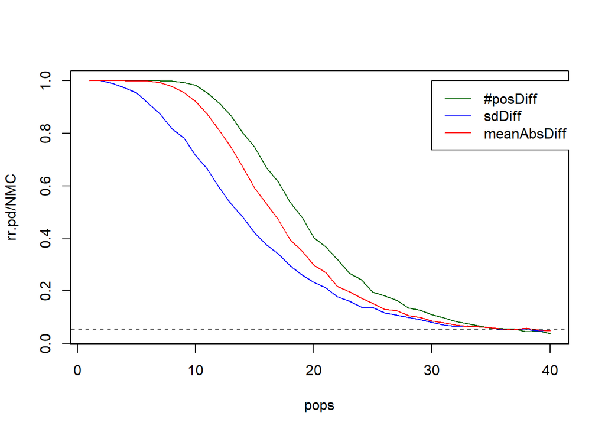

```r
shuffleN <- function(x,n=1){
  for(i in 1:n){
    x <- popOnce(x)
  }
  return(x)
}

maxPops <- 40
pops <- 1:maxPops
rr.pd <- rep(0,maxPops)
rr.sdd <- rep(0,maxPops)
rr.mad <- rep(0,maxPops)
NMC <- 5000

for(k in pops){
  for(i in 1:NMC){
     shuffledData <- shuffleN(1:20,k)
        #Positive Differences
        rr.pd[k] <- rr.pd[k] + (2*min(mean(t.posdiff >= count_pos_diff(shuffledData)),
            mean(t.posdiff <= count_pos_diff(shuffledData))) <=0.05 )
        #SD Differences
        rr.sdd[k] <- rr.sdd[k] + (2*min(mean(t.sddiff >= calc_sd_diff(shuffledData)),
            mean(t.sddiff <= calc_sd_diff(shuffledData))) <= 0.05)
        #Mean Abs Differences
        rr.mad[k] <- rr.mad[k] + (2*min(mean(t.meanabsdiff >= calc_mean_abs_diff(shuffledData)),
            mean(t.meanabsdiff <= calc_mean_abs_diff(shuffledData))) <=0.05)
  }
}
plot(pops, rr.pd/NMC, type="l", col="darkgreen")
lines(pops, rr.sdd/NMC, col="blue")
lines(pops, rr.mad/NMC, col="red")
legend(col=c("darkgreen","blue","red"), x=maxPops*.75, y=1, legend=c("#posDiff","sdDiff","meanAbsDiff"), lty=1)
abline(h=0.05, lty=2)
```